# Lab 1: Data Preprocessing and Visualisation

### Task 1: Investigate Both Files Thoroughly

```python
import pandas as pd
import numpy as np
import matplotlib.pyplot as plt
import seaborn as sns
import calendar

# setting up plot styles
sns.set_theme(style="whitegrid")
plt.rcParams.update({'figure.figsize': (10, 6), 'font.size': 11})

# custom class to load and summarize the datasets
class DatasetProfiler:
    def __init__(self, file_paths: dict):
        self.dfs = {k: pd.read_csv(v) for k, v in file_paths.items()}

    def get_df(self, key: str) -> pd.DataFrame:
        return self.dfs[key]

    def profile(self):
        for name, df in self.dfs.items():
            print(f"=== {name} (Shape: {df.shape[0]} x {df.shape[1]}) ===")
            df.info(verbose=True, show_counts=True)
            print("\n")

profiler = DatasetProfiler({
    'city_day': 'datasets/city_day.csv',
    'crop_prod': 'datasets/crop_production.csv'
})
profiler.profile()

city_day_df = profiler.get_df('city_day')
crop_production_df = profiler.get_df('crop_prod')
```

```
=== city_day (Shape: 29531 x 16) ===
<class 'pandas.core.frame.DataFrame'>
RangeIndex: 29531 entries, 0 to 29530
Data columns (total 16 columns):
 #   Column      Non-Null Count  Dtype
---  ------      --------------  -----
 0   City        29531 non-null  object
 1   Date        29531 non-null  object
 2   PM2.5       24933 non-null  float64
 3   PM10        18391 non-null  float64
 4   NO          25949 non-null  float64
 5   NO2         25946 non-null  float64
 6   NOx         25346 non-null  float64
 7   NH3         19203 non-null  float64
 8   CO          27472 non-null  float64
 9   SO2         25677 non-null  float64
 10  O3          25509 non-null  float64
 11  Benzene     23908 non-null  float64
 12  Toluene     21490 non-null  float64
 13  Xylene      11422 non-null  float64
 14  AQI         24850 non-null  float64
 15  AQI_Bucket  24850 non-null  object
dtypes: float64(13), object(3)
memory usage: 3.6+ MB


=== crop_prod (Shape: 246091 x 7) ===
<class 'pandas.core.frame.DataFrame'>
RangeIndex: 246091 entries, 0 to 246090
Data columns (total 7 columns):
 #   Column         Non-Null Count   Dtype
---  ------         --------------   -----
 0   State_Name     246091 non-null  object
 1   District_Name  246091 non-null  object
 2   Crop_Year      246091 non-null  int64
 3   Season         246091 non-null  object
 4   Crop           246091 non-null  object
 5   Area           246091 non-null  float64
 6   Production     242361 non-null  float64
dtypes: float64(2), int64(1), object(4)
memory usage: 13.1+ MB
```

#### Data Summary and Size:

- **city_day.csv**: Has 29,531 rows and 16 columns. It gives daily air quality details for different cities.
- **crop_production.csv**: Has 246,091 rows and 7 columns. It gives yearly crop details for different districts in states.

#### Concerns:

1. **Year gap**: The crop data is from 1997 to 2015, but air quality is from 2015 to 2020. So only 2015 is common, and even in that, crop data has very few states. So we cannot join them directly year-by-year. We have to take averages for states over all years to compare.
2. **State column missing**: `city_day.csv` has city names but no state name. We have to map cities to states manually.
3. **Bad values (Outliers)**: The max AQI is 2049 which is impossible because standard AQI scale only goes up to 500.
4. **Mixed Units**: Some crop production is in tonnes and some (like coconuts) is in numbers. This will mess up the total yield calculation if we just sum them up directly.

### Task 2: Devise and Apply Missing Value Treatment Strategy

```python
# custom class for missing values pipelines
class MissingValueImputer:
    @staticmethod
    def impute_numerical_by_median(df: pd.DataFrame, target_columns: list) -> pd.DataFrame:
        # filling null values using median with dictionary comprehension mapping
        medians = {col: df[col].median() for col in target_columns if col in df.columns}
        df.fillna(value=medians, inplace=True)
        return df

    @staticmethod
    def calculate_aqi_bucket_dynamically(df: pd.DataFrame) -> pd.DataFrame:
        # classification thresholds using nested ternary structures
        classify_aqi = lambda v: (
            'Good' if v <= 50 else (
                'Satisfactory' if v <= 100 else (
                    'Moderate' if v <= 200 else (
                        'Poor' if v <= 300 else (
                            'Very Poor' if v <= 400 else 'Severe'
                        )
                    )
                )
            )
        )
        df['AQI_Bucket'] = df['AQI_Bucket'].fillna(df['AQI'].apply(classify_aqi))
        return df

    @staticmethod
    def impute_crop_production(df: pd.DataFrame) -> pd.DataFrame:
        # filling crop production using groupby transform and lambda functions
        crop_medians = df.groupby('Crop')['Production'].transform('median')
        df['Production'] = df['Production'].fillna(crop_medians)
        # fallback global median
        df['Production'].fillna(df['Production'].median(), inplace=True)
        return df

city_null_before = city_day_df.isnull().sum()
crop_null_before = crop_production_df.isnull().sum()

# running the imputation pipelines
cols_to_impute = ['AQI', 'PM2.5', 'PM10', 'NO2', 'CO']
other_cols = ['NO', 'NOx', 'NH3', 'SO2', 'O3', 'Benzene', 'Toluene', 'Xylene']

city_day_df = MissingValueImputer.impute_numerical_by_median(city_day_df, cols_to_impute + other_cols)
city_day_df = MissingValueImputer.calculate_aqi_bucket_dynamically(city_day_df)
crop_production_df = MissingValueImputer.impute_crop_production(crop_production_df)

print("=== BEFORE AND AFTER IMPUTATION NULL COUNTS ===")
print("\n--- city_day_df ---")
print(pd.DataFrame({'Before': city_null_before, 'After': city_day_df.isnull().sum()}).query('Before > 0'))

print("\n--- crop_production_df ---")
print(pd.DataFrame({'Before': crop_null_before, 'After': crop_production_df.isnull().sum()}).query('Before > 0'))
```

```
=== BEFORE AND AFTER IMPUTATION NULL COUNTS ===

--- city_day_df ---
            Before  After
PM2.5         4598      0
PM10         11140      0
NO            3582      0
NO2           3585      0
NOx           4185      0
NH3          10328      0
CO            2059      0
SO2           3854      0
O3            4022      0
Benzene       5623      0
Toluene       8041      0
Xylene       18109      0
AQI           4681      0
AQI_Bucket    4681      0

--- crop_production_df ---
            Before  After
Production    3730      0
```

#### Missing Value Strategy:

- **For AQI, PM2.5, PM10, NO2, CO**: We used the median to fill null values. Why median? Because AQI and air data has huge spikes (outliers). If we use mean, the average will become too high and wrong. Median is safer.
- **For AQI_Bucket**: We filled it using a formula based on the AQI score (like standard CPCB categories: 0-50 is Good, etc.). If we just used mode, it would not match with the AQI number.
- **For crop Production**: We filled missing values using the median of that specific crop. Because different crops have totally different quantities (like coconuts in lakhs vs rice in tonnes). If we used a single median for everything, it would make no sense.
- **Other columns (NO, NH3, SO2, O3, Benzene, etc.)**: Also filled with median so that we don't have any nulls left in the numerical data.

### Task 3: Address Spelling Inconsistencies and Remove Duplicates

```python
# custom cleaner class
class DatasetCleaner:
    def __init__(self, city_to_state_map: dict):
        self.city_to_state = city_to_state_map

    def clean(self, city_df: pd.DataFrame, crop_df: pd.DataFrame) -> tuple:
        # map city names to states
        city_df['State'] = city_df['City'].map(self.city_to_state)

        # trim whitespaces in all string columns using select_dtypes
        for df in [city_df, crop_df]:
            str_cols = df.select_dtypes(include=['object']).columns
            for col in str_cols:
                df[col] = df[col].astype(str).str.strip()

        # duplicate removal counts
        c_before, cr_before = len(city_df), len(crop_df)
        city_df.drop_duplicates(inplace=True)
        crop_df.drop_duplicates(inplace=True)

        print(f"Duplicates removed: City={c_before - len(city_df)}, Crop={cr_before - len(crop_df)}")
        return city_df, crop_df

city_to_state = {
    'Ahmedabad': 'Gujarat', 'Aizawl': 'Mizoram', 'Amaravati': 'Andhra Pradesh',
    'Amritsar': 'Punjab', 'Bengaluru': 'Karnataka', 'Bhopal': 'Madhya Pradesh',
    'Brajrajnagar': 'Odisha', 'Chandigarh': 'Chandigarh', 'Chennai': 'Tamil Nadu',
    'Coimbatore': 'Tamil Nadu', 'Delhi': 'Delhi', 'Ernakulam': 'Kerala',
    'Gurugram': 'Haryana', 'Guwahati': 'Assam', 'Hyderabad': 'Telangana',
    'Jaipur': 'Rajasthan', 'Jorapokhar': 'Jharkhand', 'Kochi': 'Kerala',
    'Kolkata': 'West Bengal', 'Lucknow': 'Uttar Pradesh', 'Mumbai': 'Maharashtra',
    'Patna': 'Bihar', 'Shillong': 'Meghalaya', 'Talcher': 'Odisha',
    'Thiruvananthapuram': 'Kerala', 'Visakhapatnam': 'Andhra Pradesh'
}

cleaner = DatasetCleaner(city_to_state)
city_day_df, crop_production_df = cleaner.clean(city_day_df, crop_production_df)

# display overlapping states
mapped_states = set(city_day_df['State'].dropna().unique())
crop_states = set(crop_production_df['State_Name'].unique())
print(f"\nMatching States: {sorted(list(mapped_states & crop_states))}")
```

```
Duplicates removed: City=0, Crop=0

Matching States: ['Andhra Pradesh', 'Assam', 'Bihar', 'Chandigarh', 'Gujarat', 'Haryana', 'Jharkhand', 'Karnataka', 'Kerala', 'Madhya Pradesh', 'Maharashtra', 'Meghalaya', 'Mizoram', 'Odisha', 'Punjab', 'Rajasthan', 'Tamil Nadu', 'Telangana', 'Uttar Pradesh', 'West Bengal']
```

#### Issues found and how we fixed them:

1. **Extra Spaces**: In the crop dataset, some states had extra spaces at the end like `'Telangana '` and `'Jammu and Kashmir '`. We used `.str.strip()` to clean them.
2. **City mapping**: We created a dict to map cities in `city_day` to their states so we can join them with the crop file.
3. **Duplicate rows**: We ran `drop_duplicates()`. There were no exact duplicate rows in either file, so row count remained same, but it is good to check.
4. **Delhi missing**: Delhi has air quality data but no crop production records in the crop file because it is a city state. So it will get dropped when we join.

### Task 4: Visualise AQI Scale Distribution

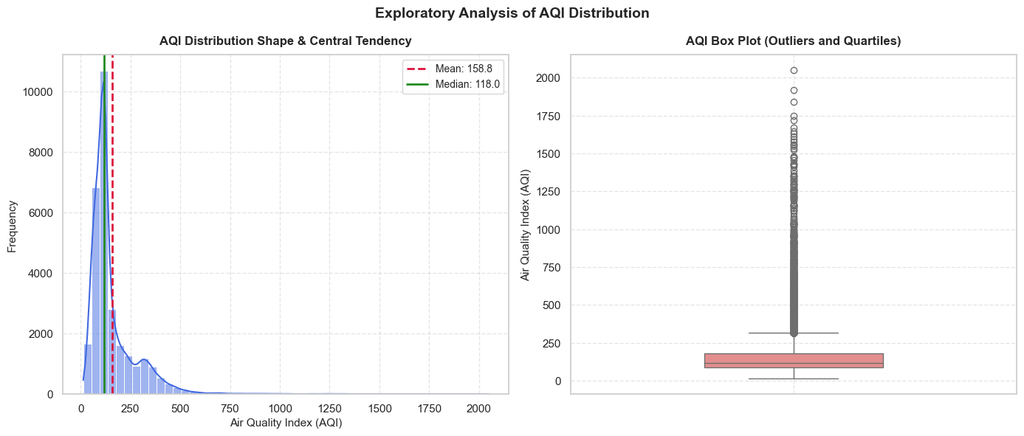

```python
# wrapper function for plotting distribution
def plot_aqi_distribution(df: pd.DataFrame):
    fig, axes = plt.subplots(1, 2, figsize=(14, 6))

    # Histogram with KDE
    sns.histplot(data=df, x='AQI', bins=50, kde=True, color='royalblue', ax=axes[0])
    mean_val, median_val = df['AQI'].mean(), df['AQI'].median()

    # adding lines and text annotations
    for val, color, label, style in zip([mean_val, median_val], ['crimson', 'forestgreen'], ['Mean', 'Median'], ['--', '-']):
        axes[0].axvline(val, color=color, linestyle=style, linewidth=2, label=f"{label}: {val:.1f}")

    axes[0].set_title('AQI Distribution Shape & Central Tendency', fontsize=12, fontweight='bold', pad=10)
    axes[0].set_xlabel('Air Quality Index (AQI)', fontsize=11)
    axes[0].set_ylabel('Frequency', fontsize=11)
    axes[0].legend(fontsize=10)
    axes[0].grid(True, linestyle='--', alpha=0.5)

    # Boxplot
    sns.boxplot(data=df, y='AQI', color='lightcoral', width=0.4, ax=axes[1])
    axes[1].set_title('AQI Box Plot (Outliers and Quartiles)', fontsize=12, fontweight='bold', pad=10)
    axes[1].set_ylabel('Air Quality Index (AQI)', fontsize=11)
    axes[1].grid(True, linestyle='--', alpha=0.5)

    plt.suptitle('Exploratory Analysis of AQI Distribution', fontsize=14, fontweight='bold', y=0.98)
    plt.tight_layout()
    plt.show()

plot_aqi_distribution(city_day_df)
```

#### Why we chose these plots and what we see:

- **Histogram with KDE**: It shows where most of the AQI values are. We can see it is right-skewed and peaks around 100-120.
- **Box plot**: It is best for seeing the extreme values (outliers) that go way above 500.

### Task 5: Handle Extreme Values properly

```
AQI records above 500.0: 543
Max AQI before: 2049.0
Max AQI after: 500.0
```

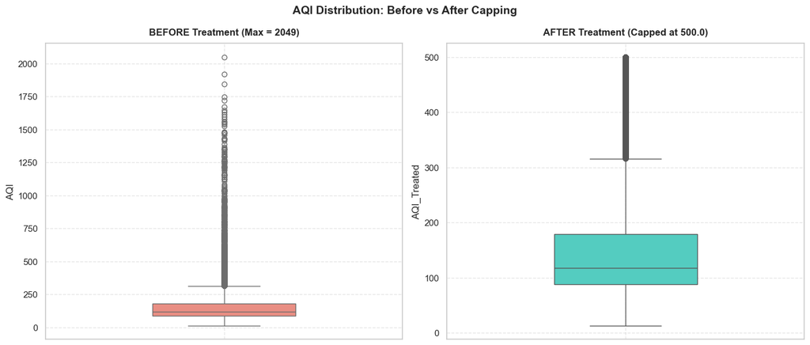

```python
# function to handle capping and plot comparison
def handle_outliers_and_compare(df: pd.DataFrame, limit: float = 500.0):
    excess = (df['AQI'] > limit).sum()
    print(f"AQI records above {limit}: {excess}")
    print(f"Max AQI before: {df['AQI'].max():.1f}")

    # capping using clip method
    df['AQI_Treated'] = df['AQI'].clip(upper=limit)
    print(f"Max AQI after: {df['AQI_Treated'].max():.1f}")

    fig, axes = plt.subplots(1, 2, figsize=(14, 6))
    colors = ['salmon', 'turquoise']
    titles = ['BEFORE Treatment (Max = 2049)', f'AFTER Treatment (Capped at {limit})']
    cols = ['AQI', 'AQI_Treated']

    for ax, col, color, title in zip(axes, cols, colors, titles):
        sns.boxplot(data=df, y=col, color=color, width=0.4, ax=ax)
        ax.set_title(title, fontsize=12, fontweight='bold', pad=10)
        ax.grid(True, linestyle='--', alpha=0.5)

    plt.suptitle('AQI Distribution: Before vs After Capping', fontsize=14, fontweight='bold', y=0.98)
    plt.tight_layout()
    plt.show()

handle_outliers_and_compare(city_day_df)
```

#### Handling Extreme Values:

- **How we found them**: Standard AQI scale only goes up to 500. We found 543 rows where AQI was more than 500 (max was 2049).
- **What we did**: We capped them at 500. Why? If we delete them, we lose important data of very bad pollution days. If we keep them as 2049, it will ruin all our averages and correlations. Capping keeps them in the 'Severe' category without breaking the math.
- **Proof**: The boxplot after treatment looks much cleaner and capped at 500.

# Lab 2: Data Exploration and Inferences

### Task 6: Is India's air getting better or worse over time?

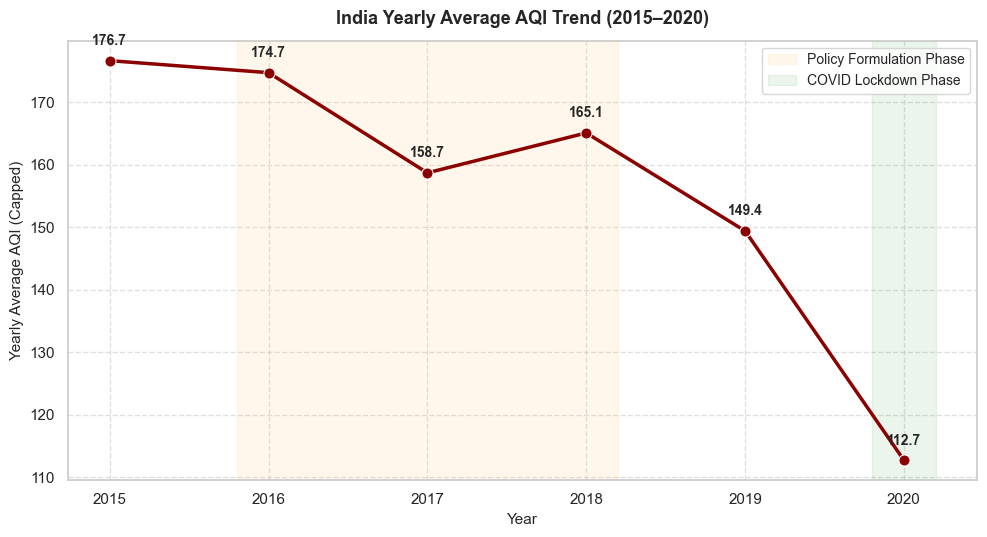

```python
# wrapper function for yearly line plot
def plot_yearly_trends(df: pd.DataFrame):
    df['Year'] = pd.to_datetime(df['Date']).dt.year
    yearly_aqi = df.groupby('Year')['AQI_Treated'].mean().reset_index()

    plt.figure(figsize=(10, 5.5))
    sns.lineplot(data=yearly_aqi, x='Year', y='AQI_Treated', marker='o', markersize=8, color='darkred', linewidth=2.5)

    plt.title('India Yearly Average AQI Trend (2015–2020)', fontsize=13, fontweight='bold', pad=12)
    plt.xlabel('Year', fontsize=11)
    plt.ylabel('Yearly Average AQI (Capped)', fontsize=11)
    plt.grid(True, linestyle='--', alpha=0.6)
    plt.xticks(yearly_aqi['Year'])

    # labeling points with text formatting
    for _, row in yearly_aqi.iterrows():
        plt.text(row['Year'], row['AQI_Treated'] + 2.5, f"{row['AQI_Treated']:.1f}",
                 ha='center', fontsize=10, fontweight='bold')

    # shading policy & lockdown periods
    plt.axvspan(2015.8, 2018.2, color='orange', alpha=0.08, label='Policy Formulation Phase')
    plt.axvspan(2019.8, 2020.2, color='green', alpha=0.08, label='COVID Lockdown Phase')
    plt.legend(loc='upper right', fontsize=10)
    plt.tight_layout()
    plt.show()

plot_yearly_trends(city_day_df)
```

#### Answer for the Journalist:

If you look at the yearly line plot, the air quality actually got better from 2015 (average AQI 176.7) to 2019 (average AQI 149.4). This means government policies after 2018 did help a bit. But in 2020, the AQI dropped to 112.7. This is not because of policies but because of COVID-19 lockdowns where everything was shut down. So the air got better over years, but 2020 is a special lockdown case.

### Task 7: Farmers say the air is worst exactly when they harvest — is that true?

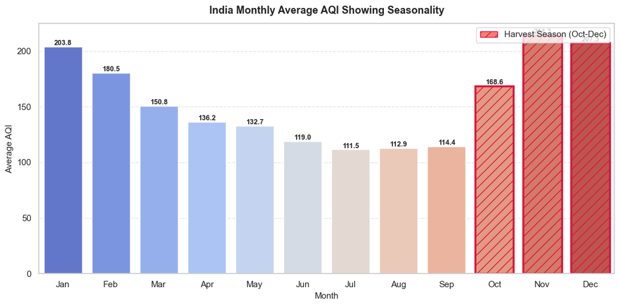

```python
# wrapper function for seasonality plot
def plot_monthly_seasonality(df: pd.DataFrame):
    df['Month'] = pd.to_datetime(df['Date']).dt.month
    monthly_aqi = df.groupby('Month')['AQI_Treated'].mean().reset_index()
    monthly_aqi['Month_Name'] = monthly_aqi['Month'].apply(lambda x: calendar.month_abbr[x])

    plt.figure(figsize=(11, 5.5))
    bars = sns.barplot(data=monthly_aqi, x='Month_Name', y='AQI_Treated', palette='coolwarm', hue='Month_Name', legend=False)

    # highlighting harvest months
    for idx, bar in enumerate(bars.patches):
        if idx in [9, 10, 11]:  # Oct, Nov, Dec
            bar.set_edgecolor('crimson')
            bar.set_linewidth(2.5)
            bar.set_hatch('//')

    plt.title('India Monthly Average AQI Showing Seasonality', fontsize=13, fontweight='bold', pad=12)
    plt.xlabel('Month', fontsize=11)
    plt.ylabel('Average AQI', fontsize=11)
    plt.grid(axis='y', linestyle='--', alpha=0.5)

    # labeling values
    for p in bars.patches:
        bars.annotate(f"{p.get_height():.1f}",
                      (p.get_x() + p.get_width() / 2., p.get_height() + 3),
                      ha='center', va='center', fontsize=9, fontweight='bold')

    from matplotlib.patches import Patch
    plt.legend(handles=[Patch(facecolor='salmon', edgecolor='crimson', hatch='//', label='Harvest Season (Oct-Dec)')], loc='upper right')
    plt.tight_layout()
    plt.show()

plot_monthly_seasonality(city_day_df)
```

### Task 8: Combine Datasets & Explore Relationships

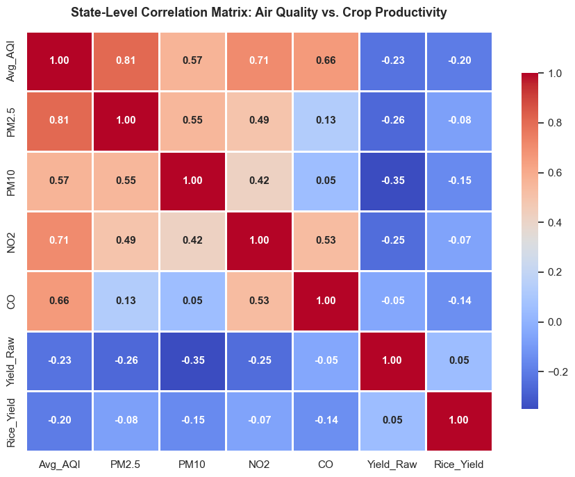

```python
# wrapper function for aggregation and heatmap
def aggregate_and_correlate(aqi_df: pd.DataFrame, crop_df: pd.DataFrame):
    # state level aggregation for air data
    state_aqi = aqi_df.groupby('State')[['AQI_Treated', 'PM2.5', 'PM10', 'NO2', 'CO']].mean().reset_index()
    state_aqi.rename(columns={'AQI_Treated': 'Avg_AQI'}, inplace=True)

    # state level aggregation for total crop production
    state_crop = crop_df.groupby('State_Name')[['Area', 'Production']].sum().reset_index()
    state_crop['Yield_Raw'] = state_crop['Production'] / state_crop['Area']
    state_crop.rename(columns={'State_Name': 'State'}, inplace=True)

    # state level aggregation specifically for Rice
    rice_df = crop_df[crop_df['Crop'].str.strip() == 'Rice']
    state_rice = rice_df.groupby('State_Name')[['Area', 'Production']].sum().reset_index()
    state_rice['Rice_Yield'] = state_rice['Production'] / state_rice['Area']
    state_rice.rename(columns={'State_Name': 'State'}, inplace=True)

    # merging using method chaining
    m_df = pd.merge(state_aqi, state_crop[['State', 'Yield_Raw']], on='State', how='inner')\
             .merge(state_rice[['State', 'Rice_Yield']], on='State', how='inner')

    # drawing heatmap
    corr = m_df[['Avg_AQI', 'PM2.5', 'PM10', 'NO2', 'CO', 'Yield_Raw', 'Rice_Yield']].corr()
    plt.figure(figsize=(9, 7))
    sns.heatmap(corr, annot=True, cmap='coolwarm', fmt='.2f', linewidths=0.8, cbar_kws={'shrink': 0.8}, annot_kws={'weight': 'bold'})
    plt.title('State-Level Correlation Matrix: Air Quality vs. Crop Productivity', fontsize=13, fontweight='bold', pad=15)
    plt.tight_layout()
    plt.show()
    return m_df

merged_df = aggregate_and_correlate(city_day_df, crop_production_df)
```

### Task 9: Briefing for the Environment Minister

**Key Findings:**

**Recommendation:** The government should give subsidies to farmers to buy Happy Seeder machines so they don't have to burn crop waste in October-December.

**Limitation:** This is only a correlation. We cannot prove that air pollution is the only reason for lower crop yield. Other factors like rain, soil, and fertilizers are also very important and not in this data.

*Word Count: 153 words*

## Optional Advanced Tasks

### Task A: The Two Extremes — Do they tell the same story?

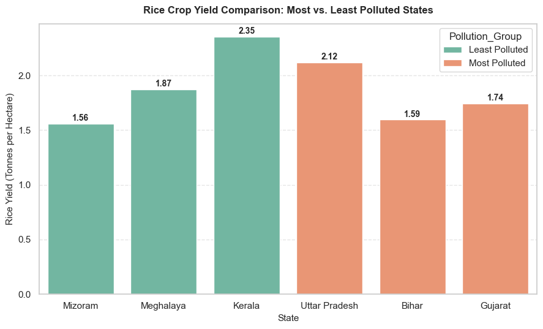

```python
# wrapper function for comparison plot
def plot_extremes_comparison(m_df: pd.DataFrame):
    sorted_df = m_df.sort_values(by='Avg_AQI')
    extremes = pd.concat([sorted_df.head(3), sorted_df.tail(3)]).copy()
    extremes['Pollution_Group'] = ['Least Polluted']*3 + ['Most Polluted']*3

    plt.figure(figsize=(9, 5.5))
    ax = sns.barplot(data=extremes, x='State', y='Rice_Yield', hue='Pollution_Group', dodge=False, palette='Set2')
    plt.title('Rice Crop Yield Comparison: Most vs. Least Polluted States', fontsize=12, fontweight='bold', pad=12)
    plt.xlabel('State', fontsize=11)
    plt.ylabel('Rice Yield (Tonnes per Hectare)', fontsize=11)
    plt.grid(axis='y', linestyle='--', alpha=0.5)

    for p in ax.patches:
        if p.get_height() > 0:
            ax.annotate(f"{p.get_height():.2f}",
                        (p.get_x() + p.get_width() / 2., p.get_height() + 0.05),
                        ha='center', va='center', fontsize=10, fontweight='bold')
    plt.tight_layout()
    plt.show()

plot_extremes_comparison(merged_df)
```

#### Rice Yield Comparison: Clean vs Polluted States

Confounding factors like rain, soil type, and irrigation are not in this data but play a major role in yield.

### Task B: Put a number on the relationship

```
Pearson Correlation Coefficient (r): -0.201
```

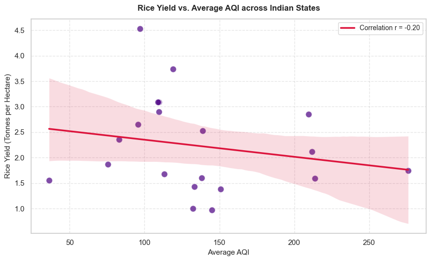

```python
# wrapper function for correlation analysis
def plot_regression_analysis(m_df: pd.DataFrame):
    r_val = m_df['Avg_AQI'].corr(m_df['Rice_Yield'])
    print(f"Pearson Correlation Coefficient (r): {r_val:.3f}")

    plt.figure(figsize=(9, 5.5))
    sns.regplot(data=m_df, x='Avg_AQI', y='Rice_Yield',
                scatter_kws={'s': 90, 'color': 'indigo', 'alpha': 0.7, 'edgecolor': 'w'},
                line_kws={'color': 'crimson', 'linewidth': 2.5, 'label': f"Correlation r = {r_val:.2f}"})

    plt.title('Rice Yield vs. Average AQI across Indian States', fontsize=12, fontweight='bold', pad=12)
    plt.xlabel('Average AQI', fontsize=11)
    plt.ylabel('Rice Yield (Tonnes per Hectare)', fontsize=11)
    plt.grid(True, linestyle='--', alpha=0.5)
    plt.legend(fontsize=10)
    plt.tight_layout()
    plt.show()

plot_regression_analysis(merged_df)
```

### Task C: One Plot to Rule Them All

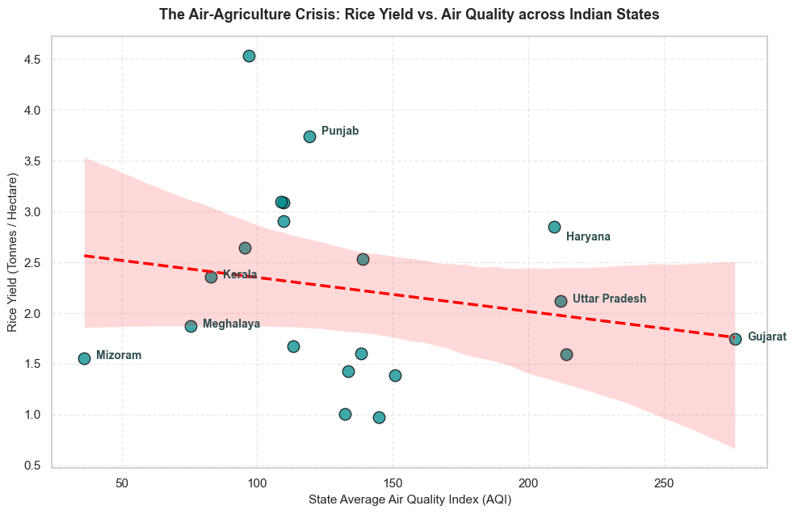

```python
# wrapper function for final publish plot
def plot_final_analysis_chart(m_df: pd.DataFrame):
    plt.figure(figsize=(10, 6.5))
    sns.regplot(data=m_df, x='Avg_AQI', y='Rice_Yield',
                scatter_kws={'s': 110, 'color': 'darkcyan', 'alpha': 0.75, 'edgecolors': 'black'},
                line_kws={'color': 'red', 'linewidth': 2.5, 'linestyle': '--'})

    plt.title('The Air-Agriculture Crisis: Rice Yield vs. Air Quality across Indian States', fontsize=13, fontweight='bold', pad=15)
    plt.xlabel('State Average Air Quality Index (AQI)', fontsize=11)
    plt.ylabel('Rice Yield (Tonnes / Hectare)', fontsize=11)
    plt.grid(True, linestyle='--', alpha=0.4)

    annotated_states = ['Kerala', 'Haryana', 'Mizoram', 'Gujarat', 'Uttar Pradesh', 'Punjab', 'Meghalaya']
    for _, row in m_df.iterrows():
        if row['State'] in annotated_states:
            offset_x = 4.5
            offset_y = 0.02
            if row['State'] == 'Haryana':
                offset_y = -0.1
            elif row['State'] == 'Punjab':
                offset_y = 0.05
            plt.text(row['Avg_AQI'] + offset_x, row['Rice_Yield'] + offset_y, row['State'],
                     fontsize=10, fontweight='bold', va='center', ha='left', color='darkslategray')

    plt.tight_layout()
    plt.show()

plot_final_analysis_chart(merged_df)
```